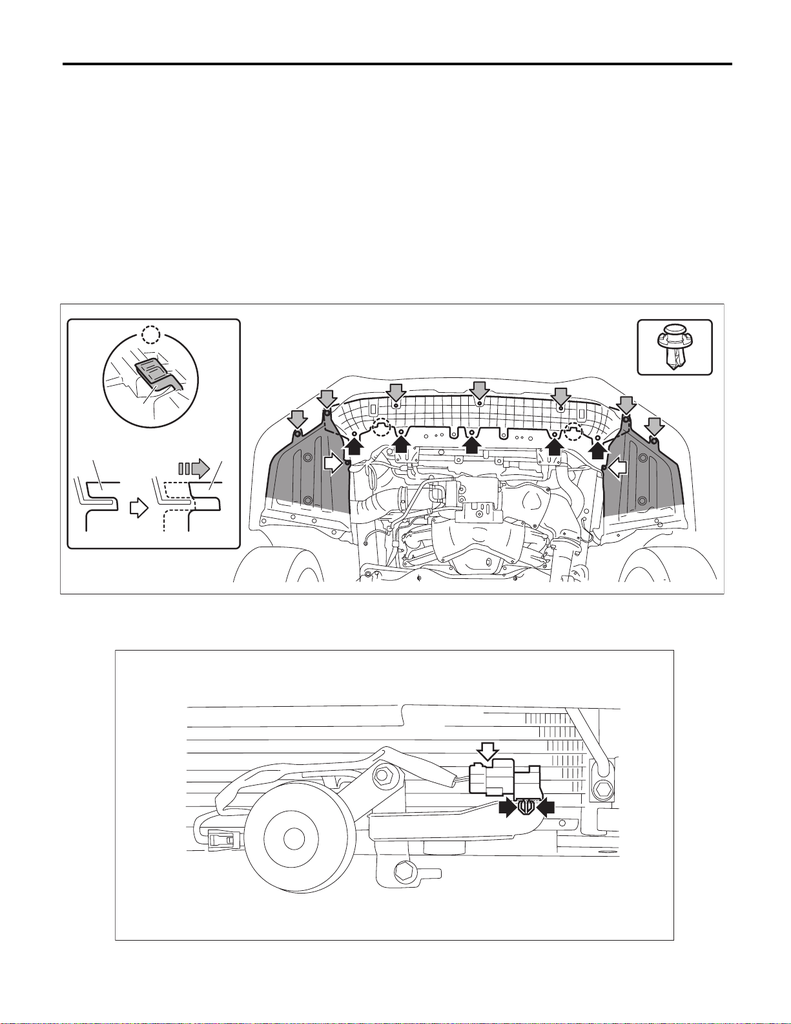

AC-72

Ambient Sensor

HVAC SYSTEM (HEATER, VENTILATOR AND A/C)

21.Ambient Sensor

A: REMOVAL

1) Disconnect the ground cable from battery. <Ref. to NT-5, BATTERY, NOTE, Note.>

NOTE:

For models other than STI model, disconnect the ground terminal from battery sensor.

2) Lift up the vehicle.

3) Remove the under cover - front. <Ref. to EI-21, REMOVAL, Front Under Cover.>

4) Remove the bracket – front center LWR.

(1) Remove the screw and clips, and turn over the mud guard - front.

(2) Remove the bolts and clips, and remove the bracket – front center LWR.

NOTE:

While entirely pushing the bracket – front center LWR forward, remove the two hooks (a) on the left and right.

5) Remove the ambient sensor.

(1) Disconnect the connector.

(2) Release the claws and remove the ambient sensor.

AC-03585

(a)

(a)

(a)

AC-03544

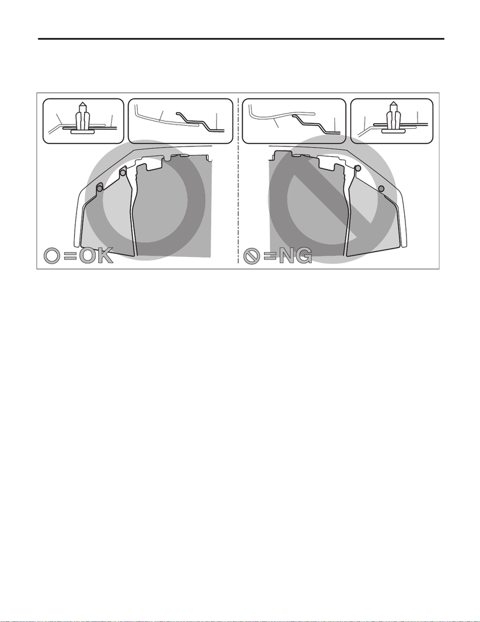

Ambient Sensor

HVAC SYSTEM (HEATER, VENTILATOR AND A/C)

B: INSTALLATION

CAUTION:

Install so that the front end of the under cover (b) comes inside the bumper face - front (a), and the

front end of the mud guard (c) comes outside the bumper face - front (a).

1) Install the ambient sensor.

2) Install the bracket – front center LWR.

Tightening torque:

7.5 N·m (0.8 kgf-m, 5.5 ft-lb)

3) Install the under cover - front.

Tightening torque:

18 N·m (1.8 kgf-m, 13.3 ft-lb)

4) Lower the vehicle.

5) Connect the battery ground terminal. <Ref. to NT-5, BATTERY, NOTE, Note.>

NOTE:

For models other than STI model, connect the ground terminal to battery sensor.

COM00138

(a)

(c)

(b)

(a)

(a)

(c)

(b)

(a)

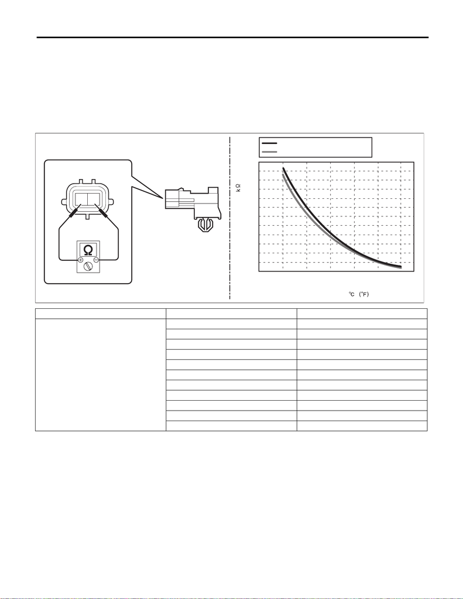

AC-74

Ambient Sensor

HVAC SYSTEM (HEATER, VENTILATOR AND A/C)

C: INSPECTION

1) Visually check the ambient sensor for dirt or damage, and clean or replace as necessary.

2) Measure the resistance between connector terminals.

CAUTION:

During inspection, be careful not to touch the sensor end in order to avoid misjudgment due to body

temperature.

Preparation tool:

Circuit tester

3) Replace the ambient sensor if the inspection result is not within the standard value.

Terminal No. Inspection conditions Standard

1 — 2

10°C 5.82 — 6.18 kΩ

15°C 4.58 — 4.87 kΩ

20°C 3.64 — 3.86 kΩ

25°C 2.91 — 3.09 kΩ

30°C 2.35 — 2.49 kΩ

35°C 1.9 — 2.02 kΩ

40°C 1.56 — 1.65 kΩ

45°C 1.28 — 1.36 kΩ

50°C 1.06 — 1.12 kΩ

55°C 0.88 — 0.93 kΩ

60°C 0.74 — 0.78 kΩ

(32)

10 20

2

1

AC-03187

1.00

1.50

2.00

2.50

3.00

3.50

4.00

4.50

5.00

5.50

6.00

6.50

TEMPERATURE

RESISTANCE VALUE